# Introduction to R

Stefani Langehennig

26/05/2020

This is a brief tutorial to get started using the programming language [R](https://www.r-project.org/about.html). R is a very well documented programming language that is developing all the time. It’s used for a number of tasks related to statistics and data science, such as Bayesian methods, unsupervised and supervised machine learning, text analytics, and data visualisation (to name a few!).

The tutorial will focus on the primary components of exploratory data analysis (EDA), including importing, manipulating, visualising, and modelling data. We will be using the [`tidyverse`](https://www.tidyverse.org/) suite of packages, which makes data analysis very easy and efficient.[^1]

### What is R?

R is an open-source programming language that anyone can freely use and can contribute to its development. It originated from the programming lanugage [S](https://bookdown.org/rdpeng/rprogdatascience/history-and-overview-of-r.html) and has become one of the most popular and powerful statistical software applications used among many disciplines. The primary reasons behind this is are two-fold: first, unlike proprietary software (Stata, SPSS, Excel), R can be downloaded and immediately put to use without licenses and fees. Second, because it’s open-source, it’s continuously evolving and on the cutting edge of statistical/data science capabilities. Finally, and perhaps most importantly, programming in general allows for reproducability and version control, which results in easier replication and error tracing.

### Installing R and R Studio

Before getting started, you will need to download R ([here](https://www.r-project.org/)) followed by R Studio ([here](https://rstudio.com/products/rstudio/download/)). While you can work in base R, I highly recommend working out of the R Studio IDE instead. In comparison to just using R, R Studio makes it much easier to manage your data, outputs, and visualisations all in one place.

### Installing and Reading in Packages

R includes more than 10,000 packages stored in its library. Packages are a collection of functions that allow you to do numerous things with minimal code. For example, if you are an Excel user, rather than typing ‘AVG()’ and ‘MEDIAN()’ to get these statitistics, these (along with other stats) are automatically spit back by calling the `summary` function that is a part of the `MASS` and `foreign` packages. You can also create your own packages containing functions, which is helpful if you are well-versed in writing macros or long formulas in Excel and want to automate the process in R.

Packages are installed using the code `install.packages()`. To retrieve the package you just installed, you use the code `library()` with the package name in the parentheses. Each time you close R and then start a new session you have to call your packages back in using the `library()` function; however, you only need to install the packages once unless you re-install or completely update R.

For the purposes of illustration, let’s install and call in the `dplyr` package that is a part of the `tidyverse` package. `dplry` is used to wrangle and manipulate data.

```r
# We use the '#' sign to annotate code and comment out code we don't want to run. I've already installed this package so I'm going to comment it out here.

#install.packages("dplyr")
library(dplyr)
```

#### A Quick Aside on the Beloved `tidyverse`

The `tidyverse` package is a magical compilation of some of the best, most robust, and most powerful packages R has to offer. The point of the tidyverse is to concentrate a suite of top-notch data science packages into one place that work in harmony with one another. Given this philosophy, all of the packages contained in the tidyverse have the same data structure, function design, and consistent syntax. Installing and calling the `tidyverse` package results in having almost all of the data science packages you need in one fell swoop. Check out the [tidyverse homepage](https://www.tidyverse.org/) if you want to learn more.

### Importing Data

There are a number of datasets that are built into R that I encourage you to play around with. They are very easy to download and can be found in the R [`datasets` package](https://stat.ethz.ch/R-manual/R-devel/library/datasets/html/00Index.html), which enables automatic data downloads once the function and dataset are called.

To illustrate importing data from outside of R’s `datasets` package, we will use data from the [Centre for learning and life chances in knowledge economies and societies (LLAKES)](https://reshare.ukdataservice.ac.uk/851427/) study, which explores inequality in lifelong learning in the UK. The data is saved as a .csv file, so we will use the `readr` package from the `tidyverse` to import it into our environment.[^2]

Below, we’ll import the file ‘perceptions_inequality.csv’ using the `read_csv` function as an intuitive object called **inequality**. Make sure the data is stored in the working directory where you are running your R session/script.

```r
#install.packages("readr")
library(readr)

inequality <- read_csv("perceptions_inequality.csv")

# take a look
glimpse(inequality)
```

[output not shown]

### Manipulating Data

We can further manipulate our **inequality** data frame object to summarise key pieces of information. For example, there is a variable in the dataset called ‘fairtreatment’ that takes the following values based on respondents’ perceptions of whether teachers treat them fairly: 1-agree strongly; 2-agree; 3-neither agree nor disagree; 4-disagree; 5-disagree strongly; 6-don’t know.

Let’s hypothesize that there will be an increase in perceptions of unfair treatment by teachers among millennial respondents, and that males will feel this more strongly than females. By futher subsetting our `inequality` dataframe to another object called `treated_fair`, we can (bluntly) test this theory. The code below generates the average for the ‘fairtreatment’ variable by respondents’ birth year and across gender (here, female and male) in the sample:

```r
treated_fair <- inequality %>%
  filter(!is.na(fairtreatment), !is.na(birth), !is.na(gender)) %>%
  mutate(birthyear = birth) %>%
  filter(birthyear >= 1982, birthyear <=1994) %>%
  group_by(birthyear, gender) %>%
  summarize(avg_fair = mean(fairtreatment))

treated_fair
```

```
## # A tibble: 24 x 3
## # Groups:   birthyear [13]
##    birthyear gender avg_fair
##        <dbl> <chr>     <dbl>
##  1      1982 Female     2
##  2      1982 Male       2
##  3      1983 Female     2
##  4      1984 Male       2.5
##  5      1985 Female     2.67
##  6      1985 Male       2.6
##  7      1986 Female     2.6
##  8      1986 Male       2.4
##  9      1987 Female     2.67
## 10      1987 Male       2
## # ... with 14 more rows
```

### Visualisation using `ggplot2`

Based on our data output above, we can see that there are some differences based on respondent birth year, as well as their self-identified gender. We can also visualise this relationship using the `ggplot2` package. The gg in `ggplot2` stands for ‘grammar of graphics’, with the user specifying the data and ggplot2 mapping it onto a set of aesthetics. It takes some time to grasp, but it very flexible and results in very nice visualisations.

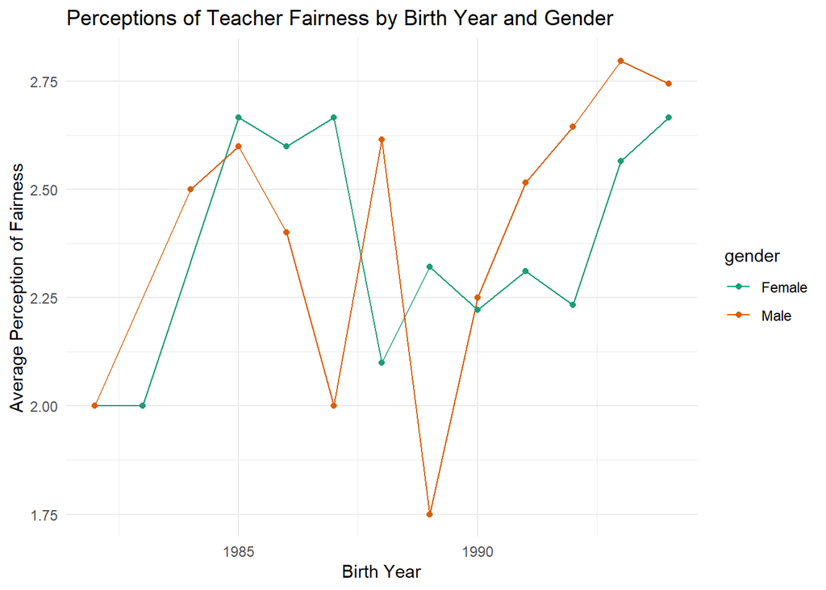

```r
library(ggplot2)

p <- ggplot(treated_fair, aes(x=birthyear, y=avg_fair, group=gender)) +
  geom_line(aes(color=gender))+
  geom_point(aes(color=gender)) +
  scale_color_brewer(palette="Dark2") +
  xlab("Birth Year") +
  ylab("Average Perception of Fairness") +
  ggtitle("Perceptions of Teacher Fairness by Birth Year and Gender")

p + theme_minimal()
```

### Resources

There are a number of resources out there to get you started and keep you learning in R. Hadley Wickham, one of R’s biggest gurus, has a wealth of resources that are free and easily accessible to beginners; a simple Google search of him will spit back enough to get you well on your way.

Other great resources include:

- [R cheat sheets](https://rstudio.com/resources/cheatsheets/)
- [R Studio Community](https://community.rstudio.com/)
- [R presence on Twitter](https://twitter.com/Rbloggers), including [We are R-ladies!](https://twitter.com/WeAreRLadies)
- [Mastering the tidyverse 1](https://www.tidyverse.org/learn/) and [2](https://moderndive.com/)
- [R for Data Science](https://r4ds.had.co.nz/)
- For more advanced stuff, see [Julia Silge’s blog](https://juliasilge.com/blog/)
[^1]: This tutorial will not cover some of the basic aspects of programming in R, such as creating functions and for-loops, but is on the docket for future tutorials.
[^2]: Note that the original data was a `.sav` (SPSS) file, which can be imported using the `haven` package. The `haven` package also allows you to import files in numerous formats, including `.dta` and `.sas`.